# Analysis for RNA-seq and ATAC-seq data in Amiri et al 2026

##### zldnoKD vs alignment control DA peaks

```r
res.zldnoKD.ac.atac <- as.data.frame(results(zld.atac.dds, contrast = c("genotype", "noKD", "ac"), independentFiltering = FALSE))
```

Add a column, “Sig”, indicating if a peak has undergone a significantly change in accessibility.

Significant DAPs will be peaks with a LFC >= 1 or LFC <=-1 and a padj <= 0.05

```r
res.zldnoKD.ac.atac <- res.zldnoKD.ac.atac %>% mutate(.,Sig = if_else((padj <= 0.05 & abs(log2FoldChange) >=1),TRUE,FALSE))
```

Add a column, “Change”, indicating if the change in accessibility was up or down.

```r
res.zldnoKD.ac.atac <- res.zldnoKD.ac.atac %>%
  mutate(Change = case_when(is.na(log2FoldChange) == TRUE | Sig == FALSE ~ "NA",
  log2FoldChange < 0 ~ "DOWN",
  log2FoldChange > 0 ~ "UP"))
```

Add a column, “peak.name”, with the peak name.

```r
res.zldnoKD.ac.atac <- res.zldnoKD.ac.atac %>% mutate(.,peak.name=rownames(.))
res.zldnoKD.ac.atac $gene_locus<-peak_annotation[match(res.zldnoKD.ac.atac$peak.name,row.names(peak_annotation)),]$geneId
```

MA plot

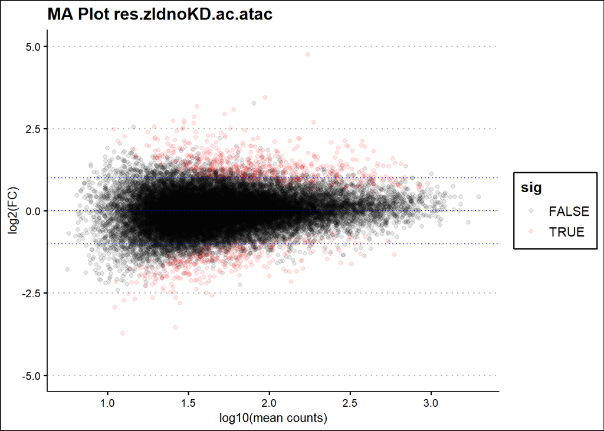

```r
res.zldnoKD.ac.atac %>%
  mutate(sig = padj <= 0.05) %>%
  ggplot(aes(x = log10(baseMean), y = log2FoldChange, color = sig)) +
  geom_point(alpha = 0.1) +
  coord_cartesian(ylim = c(-5,5)) +
  scale_color_manual(values = c("TRUE" = "red", "FALSE" =  "black")) +
  geom_hline(yintercept = c(0,1,-1), linetype = 'dotted', color = 'blue') +
  theme_clean() +
  labs(title = "MA Plot res.zldnoKD.ac.atac",
       x = "log10(mean counts)",
       y = "log2(FC)")
```

Lets plot the result and highlight significant DAPs. For this plot sig DAPs will be highlighted, and the number of DAPs that go up or down will be quantified. The size of each data point will correspond to the intensity of the peak.

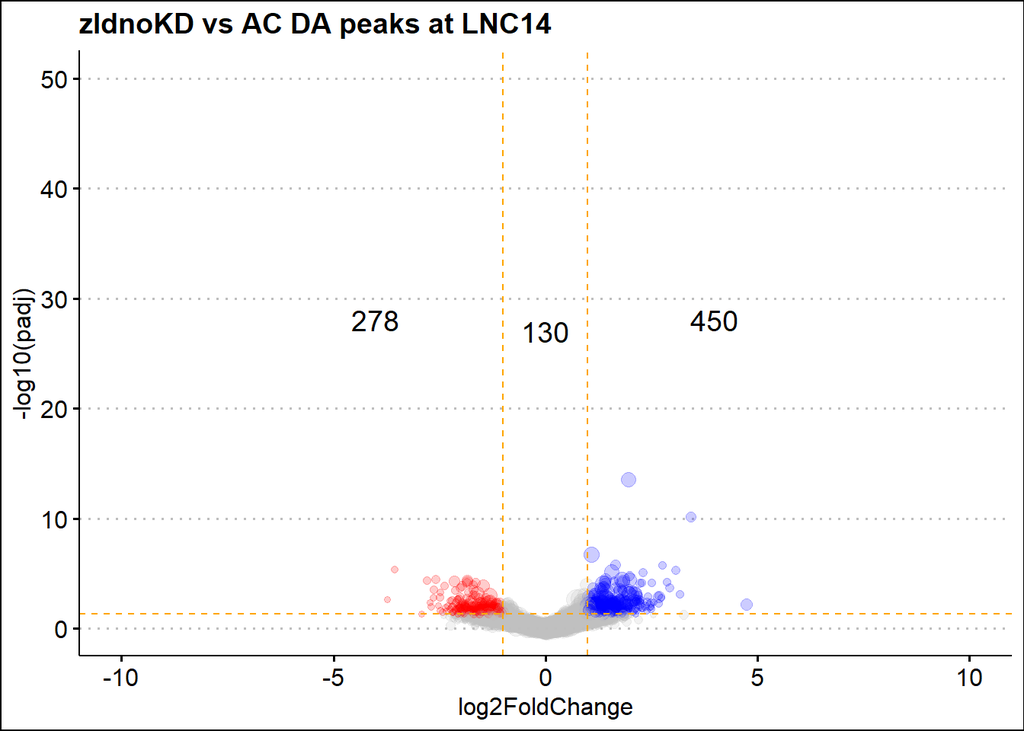

```r
#pdf(file = "../vol_zldnoKDvsAC.pdf", width = 5, height = 5)

zldnoKD.ac.vol.atac <- res.zldnoKD.ac.atac %>%
  mutate(mean.intensity = baseMean/max(baseMean)) %>%
  ggplot(aes(x = log2FoldChange, y = -log10(padj), color = Change, size = mean.intensity)) +
  geom_point(alpha = 0.2) +
  coord_cartesian(xlim = c(-10, 10), ylim = c(0, 50)) +
  geom_hline(yintercept = -log10(0.05), linetype = 'dashed', col = 'orange') +
  geom_vline(xintercept = log2(c(0.5, 2)), linetype = 'dashed', col = 'orange') +
  scale_color_manual(values = c("DOWN" = 'red', "UP" = "blue", "NA" = "grey")) +

  theme_clean(base_size = 12) + theme(legend.position = "none")+

  theme(
    plot.title = element_text(size = 14),
    axis.title = element_text(size = 12),
    axis.text = element_text(size = 12)
  ) +
  labs(title = 'zldnoKD vs AC DA peaks at LNC14')

zldnoKD.ac.vol.atac +
  annotate(geom = "text", x = -4, y = 28,
           label = length(which(res.zldnoKD.ac.atac$padj <= 0.05 & res.zldnoKD.ac.atac$log2FoldChange <= -1)),
           size = 5) +

  annotate(geom = "text", x = 4, y = 28,
           label = length(which(res.zldnoKD.ac.atac$padj <= 0.05 & res.zldnoKD.ac.atac$log2FoldChange >= 1)),
           size = 5) +

  annotate(geom = 'text', x = 0, y = 27,
           label = length(which(res.zldnoKD.ac.atac$padj <= 0.05 & abs(res.zldnoKD.ac.atac$log2FoldChange) < 1)),
           size = 5)
```

```r
#dev.off()
```

##### zldKD vs zldnokD control DA peaks

```r
res.zld.noKD.atac <- as.data.frame(results(zld.atac.dds, contrast = c("genotype", "zld", "noKD"), independentFiltering = FALSE))
```

Add a column, “Sig”, indicating if a peak has undergone a significantly change in accessibility.

Significant DAPs will be peaks with a LFC >= 1 or LFC <=-1 and a padj <= 0.05

```r
res.zld.noKD.atac <- res.zld.noKD.atac %>% mutate(.,Sig = if_else((padj <= 0.05 & abs(log2FoldChange) >=1),TRUE,FALSE))
```

Add a column, “Change”, indicating if the change in accessibility was up or down.

```r
res.zld.noKD.atac <- res.zld.noKD.atac %>%
  mutate(Change = case_when(is.na(log2FoldChange) == TRUE | Sig == FALSE ~ "NA",
  log2FoldChange < 0 ~ "DOWN",
  log2FoldChange > 0 ~ "UP"))
```

Add a column, “peak.name”, with the peak name.

```r
res.zld.noKD.atac <- res.zld.noKD.atac %>% mutate(.,peak.name=rownames(.))
res.zld.noKD.atac$gene_locus<-peak_annotation[match(res.zld.noKD.atac $peak.name,row.names(peak_annotation)),]$geneId
```

Lets plot the result and highlight significant DAPs. For this plot sig DAPs will be highlighted, and the number of DAPs that go up or down will be quantified. The size of each data point will correspond to the intensity of the peak.

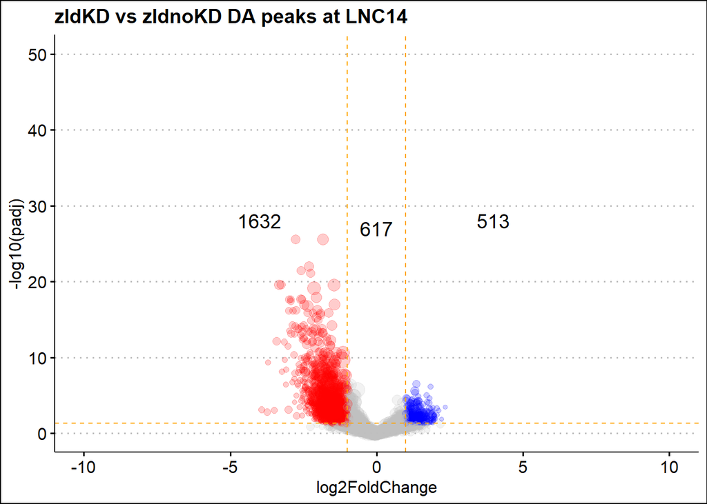

```r
#pdf(file = "../vol_zldvszldnoKD.pdf", width = 5,height = 5)


zld.zldnoD.ac.vol.atac <- res.zld.noKD.atac %>%
  mutate(mean.intensity = baseMean/max(baseMean)) %>%
  ggplot(aes(x = log2FoldChange, y = -log10(padj), color = Change, size = mean.intensity)) +
  geom_point(alpha = 0.2) +
  coord_cartesian(xlim = c(-10, 10), ylim = c(0, 50)) +
  geom_hline(yintercept = -log10(0.05), linetype = 'dashed', col = 'orange') +
  geom_vline(xintercept = log2(c(0.5, 2)), linetype = 'dashed', col = 'orange') +
  scale_color_manual(values = c("DOWN" = 'red', "UP" = "blue", "NA" = "grey")) +

  theme_clean(base_size = 12) + theme(legend.position = "none")+


  theme(
    plot.title = element_text(size = 14),
    axis.title = element_text(size = 12),
    axis.text = element_text(size = 12)
  ) +
  labs(title = 'zldKD vs zldnoKD DA peaks at LNC14')

zld.zldnoD.ac.vol.atac +
  annotate(geom = "text", x = -4, y = 28,
           label = length(which(res.zld.noKD.atac$padj <= 0.05 & res.zld.noKD.atac$log2FoldChange <= -1)),
           size = 5) +

  annotate(geom = "text", x = 4, y = 28,
           label = length(which(res.zld.noKD.atac$padj <= 0.05 & res.zld.noKD.atac$log2FoldChange >= 1)),
           size = 5) +

  annotate(geom = 'text', x = 0, y = 27,
           label = length(which(res.zld.noKD.atac$padj <= 0.05 & abs(res.zld.noKD.atac$log2FoldChange) < 1)),
           size = 5)
```

```r
#dev.off()
```

##### WT vs AC DA peaks

```r
res.wt.ac.atac <- as.data.frame(results(zld.atac.dds, contrast = c("genotype", "wt", "ac"), independentFiltering = FALSE))
```

Add a column, “Sig”, indicating if a peak has undergone a significantly change in accessibility.

Significant DAPs will be peaks with a LFC >= 1 or LFC <=-1 and a padj <= 0.05

```r
res.wt.ac.atac <- res.wt.ac.atac %>% mutate(.,Sig = if_else((padj <= 0.05 & abs(log2FoldChange) >=1),TRUE,FALSE))
```

Add a column, “Change”, indicating if the change in accessibility was up or down.

```r
res.wt.ac.atac <- res.wt.ac.atac %>%
  mutate(Change = case_when(is.na(log2FoldChange) == TRUE | Sig == FALSE ~ "NA",
  log2FoldChange < 0 ~ "DOWN",
  log2FoldChange > 0 ~ "UP"))
```

Add a column, “peak.name”, with the peak name.

```r
res.wt.ac.atac <- res.wt.ac.atac %>% mutate(.,peak.name=rownames(.))
res.wt.ac.atac$gene_locus<-peak_annotation[match(res.wt.ac.atac$peak.name,row.names(peak_annotation)),]$geneId
```

Lets plot the result and highlight significant DAPs. For this plot sig DAPs will be highlighted, and the number of DAPs that go up or down will be quantified. The size of each data point will correspond to the intensity of the peak.

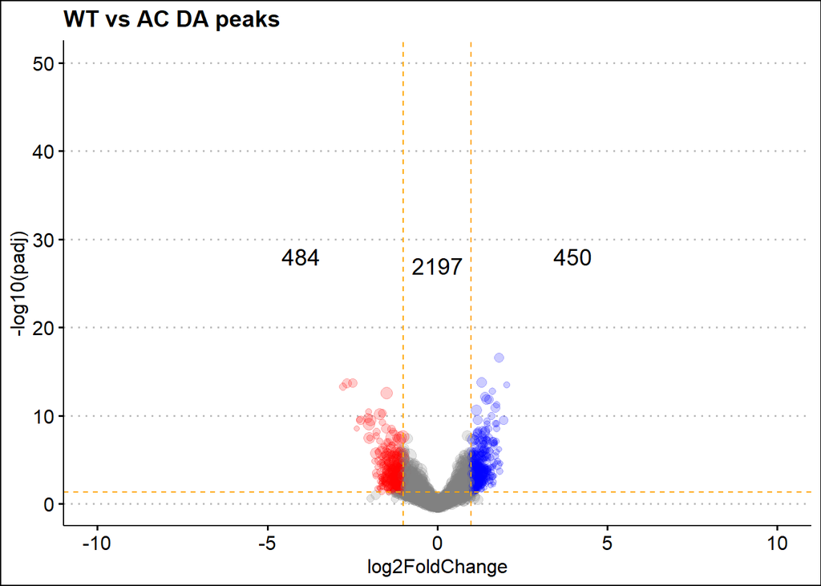

```r
#pdf(file = "../vol_wt_vs_ac.pdf", width = 5,height = 5)

wt.ac.vol.atac <- res.wt.ac.atac %>%
  mutate(mean.intensity = baseMean/max(baseMean, na.rm = TRUE)) %>%
  ggplot(aes(x = log2FoldChange, y = -log10(padj), color = Change, size = mean.intensity)) +
  geom_point(alpha = 0.2) +
  coord_cartesian(xlim = c(-10, 10), ylim = c(0, 50)) +
  geom_hline(yintercept = -log10(0.05), linetype = 'dashed', col = 'orange') +
  geom_vline(xintercept = log2(c(0.5, 2)), linetype = 'dashed', col = 'orange') +
  scale_color_manual(values = c("DOWN" = 'red', "UP" = "blue", "NS" = "grey")) +
  theme_clean(base_size = 12) + theme(legend.position = "none")+
  theme(
    plot.title = element_text(size = 14),
    axis.title = element_text(size = 12),
    axis.text = element_text(size = 12)
  ) +
  labs(title = 'WT vs AC DA peaks')

wt.ac.vol.atac +
  annotate(geom = "text", x = -4, y = 28,
           label = sum(res.wt.ac.atac$padj <= 0.05 & res.wt.ac.atac$log2FoldChange <= -1),
           size = 5) +
  annotate(geom = "text", x = 4, y = 28,
           label = sum(res.wt.ac.atac$padj <= 0.05 & res.wt.ac.atac$log2FoldChange >= 1),
           size = 5) +
  annotate(geom = 'text', x = 0, y = 27,
           label = sum(res.wt.ac.atac$padj <= 0.05 & abs(res.wt.ac.atac$log2FoldChange) < 1),
           size = 5)
```

```r
#dev.off()
```

##### Save zld ATAC DAP results

```r
res.zld.ac.atac<-res.zld.ac.atac%>%
  merge(x=.,y=genomic.feature.peaks, by = "peak.name",all.x = TRUE)  %>%
  merge(x=.,y=motif.table, by = "peak.name",all.x = TRUE) %>% mutate(best_hit_in_Dme=blast.data[gene_locus,]$gene_name)

res.zld.noKD.atac<-res.zld.noKD.atac%>%
  merge(x=.,y=genomic.feature.peaks, by = "peak.name",all.x = TRUE)  %>%
  merge(x=.,y=motif.table, by = "peak.name",all.x = TRUE) %>% mutate(best_hit_in_Dme=blast.data[gene_locus,]$gene_name)

res.zldnoKD.ac.atac<-res.zldnoKD.ac.atac%>%
  merge(x=.,y=genomic.feature.peaks, by = "peak.name",all.x = TRUE)  %>%
  merge(x=.,y=motif.table, by = "peak.name",all.x = TRUE) %>% mutate(best_hit_in_Dme=blast.data[gene_locus,]$gene_name)

write_xlsx(list("zldKD.ac.ATAC"=res.zld.ac.atac,"zldKD.zldnoKD.ATAC"=res.zld.noKD.atac,"res.zldnoKD.ac.atac"=res.zldnoKD.ac.atac), paste0(zld.results.folder, "zld_daps_all.xlsx"))
```

### 5. MEME Cal-zld KD

We will use MEME to identify motifs enriched in Cal-zld sensitive peaks.

MEME will be performed on all Cal-zld sensitive peaks, Cal-zld sensitive peaks that lose accessibility and Cal-zld sensitive peaks that gain accessibility.

We will extract sequences for each peak group and for a set of background sequences as done in previous sections.

```r
zld.ac.daps.up <- res.zld.ac.atac %>% filter(.,Sig == TRUE & Change == "UP") %>% rownames()

zld.ac.daps.down <- res.zld.ac.atac %>% filter(.,Sig == TRUE & Change == "DOWN") %>% rownames()

zld.ac.daps.all <- res.zld.ac.atac %>% filter(.,Sig == TRUE & Change == "UP" | Sig == TRUE & Change == "DOWN") %>% rownames()

zld.ac.daps.BG<-res.zld.ac.atac %>% filter(.,Sig == FALSE)%>%rownames()
```

```r
zld.noKD.daps.up <- res.zld.noKD.atac %>% filter(.,Sig == TRUE & Change == "UP") %>% rownames()

zld.noKD.daps.down <- res.zld.noKD.atac %>% filter(.,Sig == TRUE & Change == "DOWN") %>% rownames()

zld.noKD.daps.all <- res.zld.noKD.atac %>% filter(.,Sig == TRUE & Change == "UP" | Sig == TRUE & Change == "DOWN") %>% rownames()

zld.noKD.daps.BG<-res.zld.noKD.atac%>%filter(.,Sig == FALSE) %>% rownames()
```

```r
wt.ac.daps.up <- res.wt.ac.atac %>% filter(.,Sig == TRUE & Change == "UP") %>% rownames()

wt.ac.daps.down <- res.wt.ac.atac %>% filter(.,Sig == TRUE & Change == "DOWN") %>% rownames()

wt.ac.daps.all <- res.wt.ac.atac %>% filter(.,Sig == TRUE & Change == "UP" | Sig == TRUE & Change == "DOWN") %>% rownames()

wt.ac.daps.BG<-res.wt.ac.atac %>%filter(.,Sig == FALSE) %>% rownames()
```

```r
zldnoKD.ac.daps.up <- res.zldnoKD.ac.atac %>% filter(.,Sig == TRUE & Change == "UP") %>% rownames()

zldnoKD.ac.daps.down <- res.zldnoKD.ac.atac %>% filter(.,Sig == TRUE & Change == "DOWN") %>% rownames()

zldnoKD.ac.daps.all <- res.zldnoKD.ac.atac %>% filter(.,Sig == TRUE & Change == "UP" | Sig == TRUE & Change == "DOWN") %>% rownames()

zldnoKD.ac.daps.BG<-res.zldnoKD.ac.atac %>% filter(.,Sig == FALSE ) %>% rownames()
```

peaks that are not sensitive to any treatment as background for MEME analysis

```r
zld.daps.all.BG<-common_names <- Reduce(intersect, list(zld.ac.daps.BG,wt.ac.daps.BG,zld.noKD.daps.BG, zldnoKD.ac.daps.BG))
```

Get sequences for each peak group using the get.my.seqs function.

```r
sequence.output.directory <-"../MEME"
# dir for output
set.seed(124) # set seed for sampling

bgset <- sample(peaks.32157[zld.daps.all.BG], size = 1000)
start(bgset) <- bgset$max
end(bgset) <- bgset$max
bgset <- resize(bgset, width = 100, fix = "center")
bgseqs <- getSeq(Calbipunctata, bgset)

export(bgseqs, con = paste0(sequence.output.directory, "/zld-BGall-1K.txt"), format = "fasta")

get.my.seqs(p = peaks.32157[names(peaks.32157) %in% zld.ac.daps.down], dir = sequence.output.directory, name = "zld.ac-daps-down")
get.my.seqs(p = peaks.32157[names(peaks.32157) %in% zld.ac.daps.up], dir = sequence.output.directory, name = "zld.ac-daps-up")
get.my.seqs(p = peaks.32157[names(peaks.32157) %in% zld.ac.daps.all], dir = sequence.output.directory, name = "zld.ac-daps-all")


get.my.seqs(p = peaks.32157[names(peaks.32157) %in% zldnoKD.ac.daps.down], dir = sequence.output.directory, name = "zldnoKD.ac-daps-down")
get.my.seqs(p = peaks.32157[names(peaks.32157) %in% zldnoKD.ac.daps.up], dir = sequence.output.directory, name = "zldnoKD.ac-daps-up")
get.my.seqs(p = peaks.32157[names(peaks.32157) %in% zldnoKD.ac.daps.all], dir = sequence.output.directory, name = "zldnoKD.ac-daps-all")


get.my.seqs(p = peaks.32157[names(peaks.32157)%in% zld.noKD.daps.down], dir = sequence.output.directory, name = "zld.noKD-daps-down")
get.my.seqs(p = peaks.32157[names(peaks.32157) %in% zld.noKD.daps.up], dir = sequence.output.directory, name = "zld.noKD-daps-up")
get.my.seqs(p = peaks.32157[names(peaks.32157) %in% zld.noKD.daps.all], dir = sequence.output.directory, name = "zld.noKD-daps-all")

get.my.seqs(p= peaks.32157[zld.daps.all.BG], dir= sequence.output.directory, name = "zld-daps-allBG")
```

#### Find zld PWM 2

Load in the PWM from MEME. This is already a freq matrix.

```r
zldPWM2 <- as.matrix(read.table("../PWMs/zld-meme-nc11-motif6-TACCTG_freqs.txt", header = FALSE, sep =" "))

colnames(zldPWM2) <- c("A","C","G","T")
```

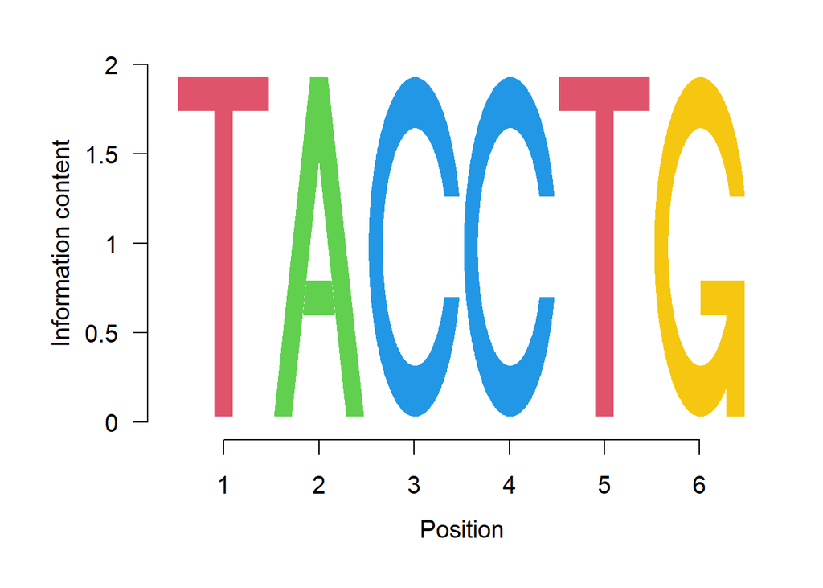

```r
tzldPWM2 <- t(zldPWM2)
seqLogo(tzldPWM2)
```

```r
# There are no low information positions to trim.
```

Save PWM.

```r
pdf(file = "../Plots/zld-meme-rc.pdf", width = 6,height = 5)

seqLogo(tzldPWM2)

dev.off()
```

(We will save time and skip this part, the updated motif table can be found in ./WT_timecourse/motif-table.txt)

zld PWM 2 in peaks.

```r
zld.peak.2 <- lapply(seq.peaks, function(x){
  matchPWM(tzldPWM2, subject = x, min.score = "80%",with.score = TRUE)
})

zld.peak.rc.2 <- lapply(seq.peaks, function(x){
  matchPWM(tzldPWM2RevCom, subject = x, min.score = "80%",with.score = TRUE)
})
```

```r
# peaks with at least one match will have a length greater than 0
n.zld.peak.2 <- zld.peak.2[lengths(zld.peak.2) > 0]
n.zld.peak.rc.2 <- zld.peak.rc.2[lengths(zld.peak.rc.2) > 0]
```

```r
paste0("percent of peaks with a zld MEME motif ",
       round(length(unique(c(names(n.zld.peak.2),names(n.zld.peak.rc.2))))/(length(peaks.32157))*100,1),"%")
```

Percent of peaks with either Zld motif

```r
paste0("percent of peaks with a zld motif ",
       round(length(unique(c(names(n.zld.peak),names(n.zld.peak.rc),names(n.zld.peak.2),names(n.zld.peak.rc.2))))/(length(peaks.32157))*100,1),"%")
```

Update the motif table

```r
zld.peaks.2.l <- names(peaks.32157) %in% names(n.zld.peak.2)
zld.peaks.rc.2.l <- names(peaks.32157) %in% names(n.zld.peak.rc.2)
```

```r
motif.table<-read_delim("../WT_timecourse/motif-table.txt")
motif.table <- data.frame(motif.table,
          zld.sites.2 = zld.peaks.2.l,
           zld.sites.rc.2 = zld.peaks.rc.2.l)


#head(motif.table)
```

All of the peaks with the first zld PWM also have the second MEME derived zld PWM

```r
all(motif.table[motif.table$zld.sites == TRUE | motif.table$zld.sites.rc,]$peak.name %in% motif.table[motif.table$zld.sites.2 == TRUE | motif.table$zld.sites.rc.2,]$peak.name)
```

SAVE updated motif table

```r
write.table(motif.table,file = "../WT_timecourse/motif-table.txt", sep = "\t", row.names = FALSE, col.names = TRUE)
```